# Pathfinder WS1 | GWS_JP

Pathfinder WS1 | GWS_JP Pre-imputation SNP QC report Leon Hubbard Antonio F. Pardiñas 19-01-2022

## Sample information

The **GWS_JP** sample contains available genotypes for 466 individuals.

There are 555737 genotyped markers. The best-guess genotyping platform based on concordant SNP coordinates is the **Human1-2M-DuoCustom_v1_A-b37**.

To maximise the number of SNPs available for imputation, we use Genome-Harmoniser (Deelen at al 2014, PMID: 25495213) to resolve strand allignment, discordant alleles and coordinate mismatches for SNPs in common between the dataset and imputation reference panel (Haplotype Reference Consortium 2016, PMID: 27548312. See http://www.haplotype-reference-consortium.org/home for more details).

## QC Step 1: SNP Missingness Rates

Markers in which the genotyping has performed poorly can be identified by assessing their call rates over the whole dataset (Turner 2011, PMID: [21234875](https://www.ncbi.nlm.nih.gov/pmc/articles/PMC3066182/)). SNPs with a low call rate are more likely to be plagued by genotyping errors, and thus should be excluded from further analyses.

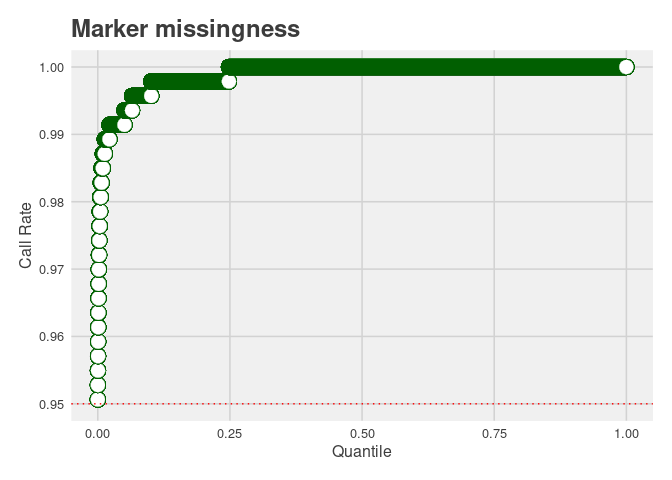

Optimal per-marker call rate was set at 95%. 0 SNPs were removed due to low call rate.

## QC Step 2: Sample Missingness Rates

Similarly to the previous step, a large proportion of SNP assays failing on a single individual may be indicative of a poor quality DNA sample, which leads to aberrant genotype calling (Turner 2011, PMID: [21234875](https://www.ncbi.nlm.nih.gov/pmc/articles/PMC3066182/)). These samples should be removed from the dataset.

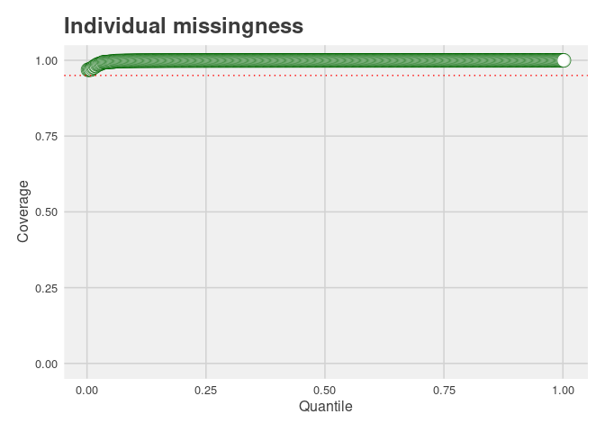

Optimal per-sample coverage was set at 95%. 0 individuals were removed due to low genotyping coverage.

## QC Step 3: Hardy-Weinberg equilibrium

Allele frequencies in random-mating populations usually follow the Hardy-Weinberg proportions, unless they are under strong selective pressures. Errors in genotyping tend to create deviations from HWE, as they result in a greater number of heterozygote calls (Graffelman 2017, PMID: [28374190](https://link.springer.com/article/10.1007%2Fs00439-017-1786-7)). At this step, only markers with large deviations from the equilibrium ($p_{mid} \leq$ $10^{-6}$) are removed.

397 SNPs were removed due to failing the HWE test.

## QC Step 4: Sex chromosome checks and abnormalities

This test assesses the match between the self-reported gender present in the PLINK files and the imputed sex inferred from homozygosity estimates from the X chromosome. Homozygosity at the X chromosome is assessed by the inbreeding coefficient F (Wright 1921, PMID: [17245962](http://www.genetics.org/content/143/4/1499)) calculated for each sample over all X-linked markers. Samples at the extremes of the distribution are likely females (low F) or males (high F).

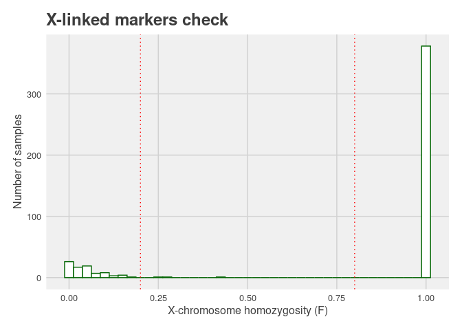

Based on X-chromosome genotypes, PLINK’s sex check function identified 0 individuals where sex was discordant between genotype and phenotype data (male sex is defined as F>=0.8 and female sex is defined as F<=0.2. In addition, 3 individuals had missing sex phenotypes. Only individuals with discordant, rather than missing gender are excluded from further QC.

If data from both sex chromosomes are present, call rates at the Y-chromosome are used to assess the presence of individuals with sex-linked chromosomal disorders such as Turner (X0) or Klinefelter (XXY) syndromes. (Igo 2016, PMID: [27367164](https://www.ncbi.nlm.nih.gov/pmc/articles/PMC5100670/)). The call rate at the Y-chromosome also allows to distinguish the sex of moderately ambiguous samples.

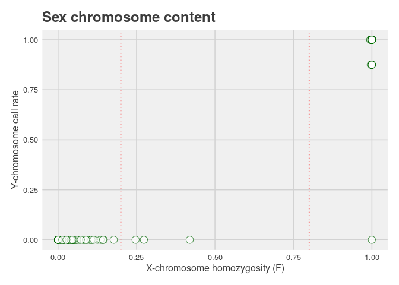

## QC Step 5: Relatedness

The SNPRelate R-package was used to convert the PLINK data into a Genomic Data Structure (GDS) file for use with the GENESIS suite. The current implementation of GENESIS provides functions to perform PC-AiR (Conomos 2015, PMID: [25810074](https://onlinelibrary.wiley.com/doi/abs/10.1002/gepi.21896)) and PC-Relate (Conomos 2016, PMID: [26748516](https://www.sciencedirect.com/science/article/pii/S0002929715004930)). PC-AiR performs a Principal Components Analysis on genome-wide SNP data for the detection of population structure in a sample that may contain known or cryptic relatedness. Unlike standard PCA, PC-AiR accounts for relatedness in the sample to provide accurate ancestry inference that is not confounded by family structure.

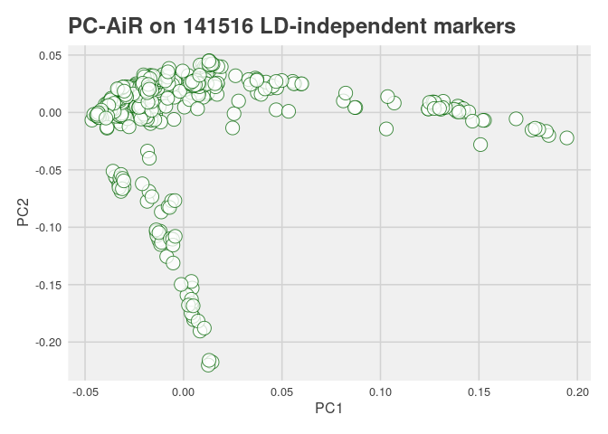

PC-Relate uses these ancestry-representative principal components to adjust for population structure and accurately estimate measures of recent genetic relatedness, of which the one of interest here is the kinship coefficient $\Phi$. This can be interpreted in the same way as the PLINK relatedness metric $\hat\pi{}$. Kinship values and proportions of SNPs with 0 IBD alleles are shown below, rescaled to the equivalent values produced by PLINK. These metrics can be used to identify groups of individuals with different degrees of relatedness (Manichaikul 2010, PMID: [20926424](https://www.ncbi.nlm.nih.gov/pmc/articles/PMC3025716/)).

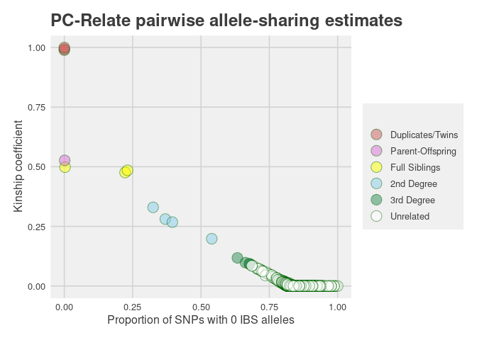

PC-Relate identified 12 pairs of individuals with kinship $\Phi\geq$ 10%. Among those, a total of 3 pairs were flagged as duplicates or monozygotic twins.

## QC Step 6: Global biogeographical ancestry inference

This analysis is based on the set of Ancestry Informative Markers (AIMs) contained in the EUROFORGEN (PMID: [24631693](https://www.sciencedirect.com/science/article/pii/S1872497314000404), [27208666](https://www.sciencedirect.com/science/article/pii/S1872497316300643)) and Kidd (PMID: [24508742](https://www.sciencedirect.com/science/article/pii/S1872497314000039)) panels. The original sets contain a grand total of 167 AIMs, but these have been restricted based on availability in the GWS_JP dataset.

As a reference panel, a combination of Human Genome Diversity Project (PMID: [18292342](http://science.sciencemag.org/content/319/5866/1100)) and South Asian Genome Project (PMID: [25115870](https://journals.plos.org/plosone/article?id=10.1371/journal.pone.0102645)) is used, which contains 1108 samples from 62 worldwide populations.

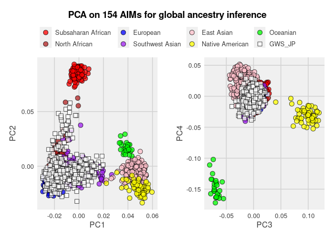

Ancestry inference is based on Fisher’s Linear Discriminant Analysis algorithm (PMID: [16193326](https://link.springer.com/article/10.1007%2Fs00439-005-0012-1)), which has been applied to the first 9 principal components of the HGDP+SAGP dataset. This optimal number of PCs has been determined using the Tracy-Widom test for eigenvalues (PMID: [17194218](https://journals.plos.org/plosgenetics/article?id=10.1371/journal.pgen.0020190)). Model training statistics for the prediction of each individual biogeographical ancestry using the available 154 AIMs are shown below.

|  | Sensitivity | Specificity | Pos Pred Value | Neg Pred Value | Balanced Accuracy |
| --- | --- | --- | --- | --- | --- |
| Subsaharan African | 97.12% | 100.00% | 100.00% | 99.64% | 98.56% |
| North African | 79.43% | 96.82% | 85.28% | 95.31% | 88.12% |
| European | 87.84% | 96.55% | 82.80% | 97.67% | 92.19% |
| Southwest Asian | 95.58% | 97.73% | 91.05% | 98.92% | 96.66% |
| East Asian | 98.28% | 100.00% | 100.00% | 99.43% | 99.14% |
| Native American | 100.00% | 99.88% | 98.44% | 100.00% | 99.94% |
| Oceanian | 100.00% | 100.00% | 100.00% | 100.00% | 100.00% |

A threshold for ancestry inference has been set at 80% probability. Any individual not achieving this probability for any ancestry has been labelled *“Unclassified”*. Inspection of GWS_JP.aim.global.prob.txt in the Ancestry folder can be helpful for the resolution of unclassified individuals, some of which might show a relatively simple admixture pattern.

| Ancestry | Samples |
| --- | --- |
| Subsaharan African | 9 |
| North African | 165 |
| European | 140 |
| Southwest Asian | 54 |
| East Asian | 0 |
| Native American | 0 |
| Oceanian | 0 |
| Unclassified | 98 |

## Miscellaneous information and directory information

540234 autosomal SNPs and 466 individuals have passed quality control.

### Genotypes

**QC’d autosomal genotypes (Plink format):** *GWS_JP.qc4.clean.bed/bim/fam*  
**QC’d autosomal genotypes (R format):** *GWS_JP.qc4.clean.gds*

### Genotypes/YChr and/or Genotypes/Mito

**Non-QC’d Y Chr:** *Genotypes/YChr/GWS_JP.Y.bed/bim/fam*  
**Non-QC’d Mitochondrial SNPs:** *GWS_JP.Mitochondria.bed/bim/fam*

### Genotypes/Logs

**Low quality SNPs removed:** *No SNPs were removed due to low genotyping*  
**Low quality samples removed:** *No individuals were removed due to genotype missingness*  
**Gender mismatches removed:** *GWS_JP.qc0.remove*  
**Individuals with sex chr abnormalities:** *GWS_JP.Abnormal.Sex.Chr.txt*  
**Duplicate samples identified:** *GWS_JP.qc4.pcrelate.dup*

### Ancestry/

**PC-AiR components for all curated samples:** *GWS_JP.qc4.pcair.eigenvec*  
**PC-Relate kinship estimates for partially related samples:** *GWS_JP.qc4.pcrelate.kin*  
**Ancestry classification using ancestry informative markers:** *GWS_JP.aim.global.classification.txt*

### ImputeMe/

**Sorted VCF files aligned to Haplotype Reference Consortium V1.1:** *GWS_JP.[1-22,X].qc3.clean.sorted.vcf.gz*